# Inteligencia y Analítica de Negocios

Práctica final T2 (Parte I)

Candela Vidal

• Datos: Fichero https://www.kaggle.com/fivethirtyeight/the-ultimate-halloween-candy-powerranking/data (origen: http://walthickey.com/2017/10/18/whats-the-best-halloween-candy/ ).

• Tecnologías: Python y Jupyter notebook o R/RStudio y RMarkdown.

• Fecha de entrega: Domingo, 6 de mayo de 2018, a las 23:55.

• En esta primera práctica vamos a afianzar el uso de herramientas de evaluación de modelos y validación de resultados.

```r
library(purrr)
library(tidyr)
library(ggplot2)
library(boot)
```

## 1 CARGA DEL FICHERO

Cargar el fichero de datos “./data/candy-data.csv”, definiendo para ello la información de tipos de datos necesaria para interpretar las columnas adecuadamente en el lenguaje de programación seleccionado.

```r
candy <- read.csv('./data/candy-data.csv', colClasses=c('character', rep('factor', 9),rep('numeric',3)),header = TRUE)
```

```r
summary(candy)
```

```
##  competitorname     chocolate fruity caramel peanutyalmondy nougat
##  Length:85          0:48      0:47   0:71    0:71           0:78
##  Class :character   1:37      1:38   1:14    1:14           1: 7
##  Mode  :character
##
##
##
##  crispedricewafer hard   bar    pluribus  sugarpercent     pricepercent
##  0:78             0:70   0:64   0:41     Min.   :0.0110   Min.   :0.0110
##  1: 7             1:15   1:21   1:44     1st Qu.:0.2200   1st Qu.:0.2550
##                                          Median :0.4650   Median :0.4650
##                                          Mean   :0.4786   Mean   :0.4689
##                                          3rd Qu.:0.7320   3rd Qu.:0.6510
##                                          Max.   :0.9880   Max.   :0.9760
##    winpercent
##  Min.   :22.45
##  1st Qu.:39.14
##  Median :47.83
##  Mean   :50.32
##  3rd Qu.:59.86
##  Max.   :84.18
```

Variables factor:

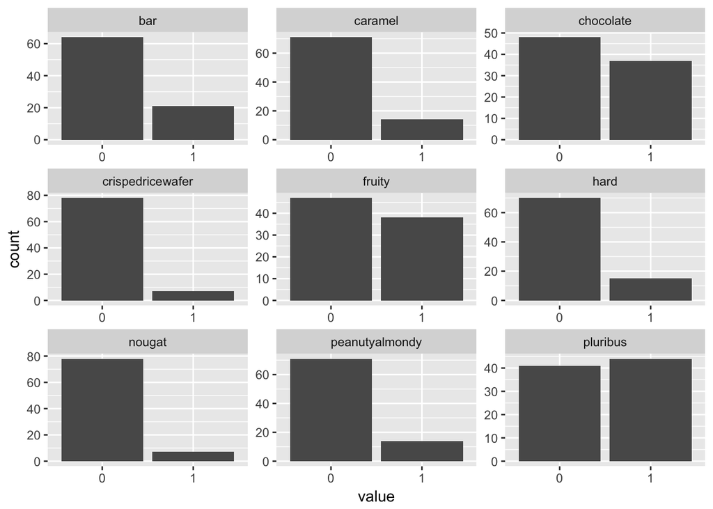

```r
candy %>%
  keep(is.factor) %>%
  gather() %>%
  ggplot(aes(value)) +
    facet_wrap(~ key, scales = "free") +
    geom_bar()
```

Variables numéricas:

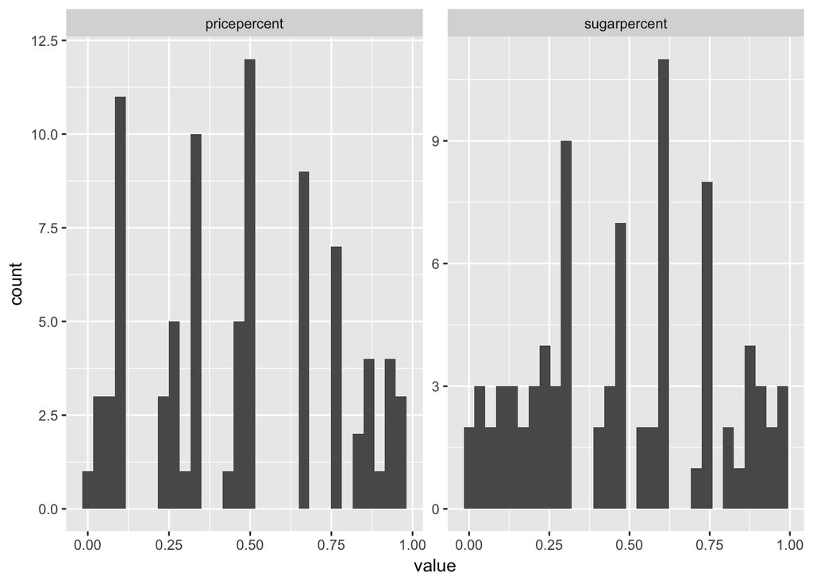

```r
candy[,-13] %>%
  keep(is.numeric) %>%
  gather() %>%
  ggplot(aes(value)) +
    facet_wrap(~ key, scales = "free") +
    geom_histogram()
```

Variable objetivo:

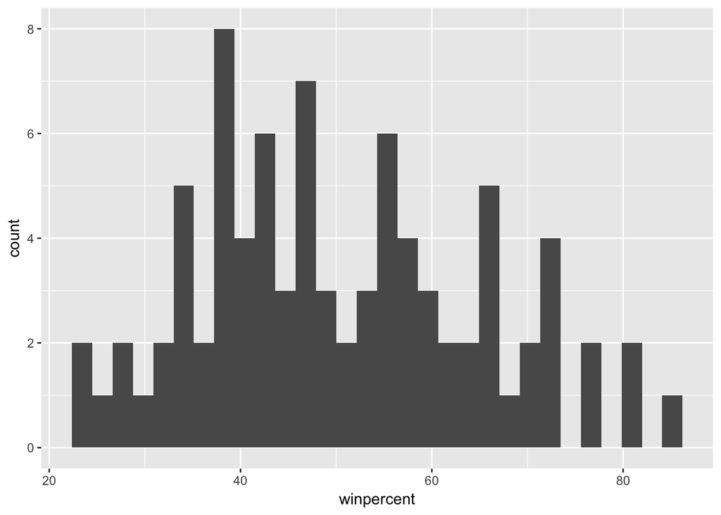

```r
ggplot(candy, aes(winpercent)) + geom_histogram()
```

## 2 MODELO y eavaluación del mismo

El modelo que debemos ajustar es una regresión mútiple, utilizando como variable de salida los valores de la columna winpercent y como variables explicativas (entrada) todas las demás columnas. El objetivo del análisis es identificar qué factores están más relacionados con la elección de un tipo de caramelo como ganador sobre los restantes.

Se pueden obtener ideas adicionales sobre cómo se han utilizado los datos para un análisis real en este post *http://fivethirtyeight.com/features/the-ultimate-halloween-candy-power-ranking/* sobre el mismo dataset.

### Apartado A : Regresión Múltiple

Primero divide la muestra total de datos en un 75% para training y un 25% para testing. Ajusta un modelo de regresión múltiple sobre los datos de training y luego comprueba su efectividad para predecir los valores de los datos de testing. (3 puntos).

```r
set.seed(1)
train.size = 0.75
train.index = sample.int(length(candy$competitorname), round(length(candy$competitorname)*train.size))
train.sample = candy[train.index,]
test.sample = candy[-train.index,]
```

Definimos el modelo de regresión sobre los datos de training e incluyendo todas las variables excepto el nombre del caramelo:

```r
glm.fit = glm( winpercent ~ chocolate + fruity + caramel + peanutyalmondy + nougat + crispedricewafer + hard + bar + pluribus + sugarpercent + pricepercent , data = train.sample)

summary(glm.fit)
```

```
##
## Call:
## glm(formula = winpercent ~ chocolate + fruity + caramel + peanutyalmondy +
##     nougat + crispedricewafer + hard + bar + pluribus + sugarpercent +
##     pricepercent, data = train.sample)
##
## Deviance Residuals:
##      Min        1Q    Median        3Q       Max
## -20.3443   -6.1558    0.9198    5.3321   19.6229
##
## Coefficients:
##                   Estimate Std. Error t value Pr(>|t|)
## (Intercept)        31.8742     5.0555   6.305 6.33e-08 ***
## chocolate1         21.5896     4.9700   4.344 6.51e-05 ***
## fruity1            14.5025     4.4242   3.278  0.00187 **
## caramel1            5.4914     4.4502   1.234  0.22276
## peanutyalmondy1    10.3473     4.1809   2.475  0.01663 *
## nougat1             0.1708     7.6627   0.022  0.98230
## crispedricewafer1   6.4627     5.6490   1.144  0.25784
## hard1              -7.6780     3.7653  -2.039  0.04653 *
## bar1                1.2664     5.7795   0.219  0.82741
## pluribus1           0.9434     3.6677   0.257  0.79802
## sugarpercent        3.7969     5.3976   0.703  0.48491
## pricepercent       -2.1758     7.1043  -0.306  0.76062
## ---
## Signif. codes:  0 '***' 0.001 '**' 0.01 '*' 0.05 '.' 0.1 ' ' 1
##
## (Dispersion parameter for gaussian family taken to be 113.5677)
##
##     Null deviance: 13509.8  on 63  degrees of freedom
## Residual deviance:  5905.5  on 52  degrees of freedom
## AIC: 497.21
##
## Number of Fisher Scoring iterations: 2
```

El MSE (error cuadrático medio) o error que comete el modelo respecto a los datos para la muestra de entrenamiento es:

```r
mean((train.sample$winpercent - predict(glm.fit, train.sample))^2)
```

```
## [1] 92.27375
```

Los valores predichos con el modelo sobre el conjunto de test frente a los valores reales son:

```r
data.frame(valor.predicho = predict(glm.fit, test.sample), valor.real = test.sample$winpercent)
```

| valor.predicho | valor.real |
| --- | --- |
| 56.08256 | 67.60294 |
| 30.80411 | 46.11650 |
| 71.36428 | 56.91455 |
| 35.55047 | 38.01096 |
| 48.98755 | 36.01763 |
| 46.78756 | 24.52499 |
| 48.07386 | 51.41243 |
| 59.93346 | 55.06407 |
| 62.21229 | 60.80070 |
| 64.26861 | 54.52645 |

[output cut: 11 more lines]

El MSE para los datos de test es:

```r
mean((test.sample$winpercent - predict(glm.fit, test.sample))^2)
```

```
## [1] 141.2835
```

Intervalos de confianza al 95% para los estimadores de los datos de train:

```r
confint(glm.fit)
```

```
##                        2.5 %    97.5 %
## (Intercept)        21.965565 41.782837
## chocolate1         11.848655 31.330615
## fruity1             5.831260 23.173654
## caramel1           -3.230746 14.213568
## peanutyalmondy1     2.152858 18.541788
## nougat1           -14.847760 15.189365
## crispedricewafer1  -4.609174 17.534671
## hard1             -15.057957 -0.298078
## bar1              -10.061139 12.594012
## pluribus1          -6.245100  8.131896
## sugarpercent       -6.782141 14.376003
## pricepercent      -16.099999 11.748304
```

Observamos que para las variables “chocolate”, “fruity”, “peanutyalmondy” y “hard” se puede afirmar con un 95% de confianza que el valor de los estimadores se encuentra los suficientemente lejos de 0 como para resultar variables significativas en el modelo.

### Apartado B : Bootstrap

Utilizando bootstrap, calcula nuevos intervalos de confianza (95%) para los estimadores de todos los regresores del modelo. ¿Son consistentes todos los valores obtenidos con los resultados del apartado anterior?. ¿Qué variables seleccionaría para mantenerlas en el modelo? (3 puntos).

La función con la que se calcularán los intevalos de confianza en el bootstrap es la siguiente:

```r
set.seed(1)

boot.fn = function(data, index) return(confint(glm( winpercent ~ chocolate + fruity + caramel + peanutyalmondy + nougat + crispedricewafer + hard + bar + pluribus + sugarpercent + pricepercent , data = data, subset = index)))
```

```r
boot.candy$t0
```

[output not shown]

```
##                          2.5 %     97.5 %
## (Intercept)        26.06713237 43.0008245
## chocolate1         12.10670697 27.3894270
## fruity1             2.04699703 16.7976471
## caramel1           -4.94381994  9.3927827
## peanutyalmondy1     2.98375770 17.1576192
## nougat1           -10.39965961 12.0083208
## crispedricewafer1  -1.40588360 19.2438232
## hard1             -12.93728170  0.6066287
## bar1               -9.47794406 10.3610243
## pluribus1          -6.81302925  5.1040302
## sugarpercent       -0.04560345 18.2191292
## pricepercent      -16.73411959  4.8773967
```

### Apartado C : k-fold validation

Ahora realiza una validación cruzada (k-fold validation) con K=5. Compara la nueva estimación del MSE con la obtenida inicialmente ¿Qué podemos concluir acerca de la robustez del modelo?. (4 puntos).

A continuación creamos un nuevo modelo utilizando todos los valores de la muestra por ser esta pequeña y seleccionando unicamente las variables que interesan (“chocolate”, “fruity”, “peanutyalmondy” y “hard”). Con ello calculamos una nueva estimación del MSE utilizando la función cv.glm y K=5.

```r
set.seed (1)
glm.cv.fit=glm(winpercent ~ chocolate + fruity + peanutyalmondy + hard, data=candy)
cv.error.5 = cv.glm(candy,glm.cv.fit,K=5)$delta
cv.error.5
```

```
## [1] 133.0276 130.3873
```

Obtenemos un vector con dos componentes. La primera es el error en crudo del MSE utilizando cross validation, mientras que la segunda tiene en cuenta el sesgo instroducido por no utilizar “leave-one-out” cross validation.

Observamos como el MSE ($133.02$) es ligeramente inferior al calculado en el apartado A para el modelo original con los datos de test ($141.28$). Esto nos induce a pensar que se trata de un modelo bastante robusto.